# exercise12

Ahmad Al Ajami

12/9/2019

## Question 1

Grab a well-known dataset, the Zheng 10x PBMC pre-sorted dataset, from ExperimentHub (see code below). Explore basic properties of this dataset, including the number cells of each subpopulation (see the phenoid column of the colData), the depth of sequencing by subpopulation and other aspects you can think of. Re-investigate the filtering (some was already) by plotting the percentage of mitochondrial reads versus the total number of reads. If appropriate, additionally filter any outlier cells:

```r
library(SingleCellExperiment)
library(ExperimentHub)
library(scater)

eh <- ExperimentHub()
sce <- eh[["EH1532"]]
rownames(sce) <- paste0(rowData(sce)$id, "_", rowData(sce)$symbol)
sce
```

```
## class: SingleCellExperiment
## dim: 15716 3994
## metadata(1): log.exprs.offset
## assays(3): counts logcounts normcounts
## rownames(15716): ENSG00000237683_AL627309.1
##   ENSG00000228327_RP11-206L10.2 ... ENSG00000215700_PNRC2
##   ENSG00000215699_SRSF10
## rowData names(10): id symbol ... total_counts log10_total_counts
## colnames(3994): b.cells1147 b.cells6276 ... naive.t1167 naive.t4926
## colData names(14): dataset barcode ... libsize.drop feature.drop
## reducedDimNames(2): PCA TSNE
## spikeNames(0):
## altExpNames(0):
```

```r
(mito <- grep("MT-", rownames(sce), value = TRUE))
```

```
##  [1] "ENSG00000198888_MT-ND1"  "ENSG00000198763_MT-ND2"
##  [3] "ENSG00000198804_MT-CO1"  "ENSG00000198712_MT-CO2"
##  [5] "ENSG00000228253_MT-ATP8" "ENSG00000198899_MT-ATP6"
##  [7] "ENSG00000198938_MT-CO3"  "ENSG00000198840_MT-ND3"
##  [9] "ENSG00000212907_MT-ND4L" "ENSG00000198886_MT-ND4"
## [11] "ENSG00000198786_MT-ND5"  "ENSG00000198695_MT-ND6"
## [13] "ENSG00000198727_MT-CYB"
```

```r
sce <- addPerCellQC(sce, subsets = list(Mt = mito))
sce <- addPerFeatureQC(sce)

phenoid <- table(sce$phenoid)
phenoid
```

```
##
##         b.cells  cd14.monocytes    cd4.t.helper         cd56.nk        memory.t
##             499             600             400             600             500
## naive.cytotoxic         naive.t    regulatory.t
##             398             499             498
```

```r
colData(sce)
```

```
## DataFrame with 3994 rows and 24 columns
##               dataset          barcode     phenoid total_features
##             <integer>      <character> <character>      <integer>
## b.cells1147         1 ACGGAGGACCGAAT-1     b.cells            427
## b.cells6276         1 GCAGCGTGCCGAAT-1     b.cells            340
## b.cells6144         1 GATTTAGAGTGTAC-1     b.cells            602
## b.cells6285         1 GCAGCTCTAGAACA-1     b.cells            410
## b.cells8679         1 TCAGTGGAGTTCAG-1     b.cells            411
## ...               ...              ...         ...            ...
## naive.t71           1 AAAGCAGAACGTTG-1     naive.t            545
## naive.t844          1 ACACGAACGCAGTT-1     naive.t            504
## naive.t5831         1 GAAGGGTGTCAAGC-1     naive.t            614
## naive.t1167         1 ACGATCGATCCCGT-1     naive.t            365
## naive.t4926         1 CGGGCATGTAAGCC-1     naive.t            498
##             log10_total_features total_counts log10_total_counts
##                        <numeric>    <numeric>          <numeric>
## b.cells1147     2.63144376901317         1096   3.04020662757471
## b.cells6276      2.5327543789925          857   2.93348728784871
## b.cells6144     2.78031731214015         1593   3.20248831706009
## b.cells6285     2.61384182187607          743   2.87157293554588
## b.cells8679     2.61489721603313         1031   3.01367969729119
## ...                          ...          ...                ...
## naive.t71       2.73719264270474         1259   3.10037054511756
## naive.t844      2.70329137811866         1259   3.10037054511756
## naive.t5831     2.78887511577542         1290   3.11092624226642
## naive.t1167     2.56348108539441          805   2.90633504180509
## naive.t4926     2.69810054562339         1224   3.08813608870055
##             pct_counts_top_50_features pct_counts_top_100_features
##                              <numeric>                   <numeric>
## b.cells1147           48.1751824817518            66.7883211678832
## b.cells6276           51.1085180863477            69.0781796966161
## b.cells6144           46.2649089767734            63.0257376020088
## b.cells6285           42.7994616419919            57.8734858681023
## b.cells8679           51.0184287099903            67.3132880698351
## ...                                ...                         ...
## naive.t71             43.6060365369341            59.0945194598888
## naive.t844            46.6243050039714            62.6687847498014
## naive.t5831           41.0077519379845            55.0387596899225
## naive.t1167           49.9378881987578            64.9689440993789
## naive.t4926           46.6503267973856            63.1535947712418
```

[output cut: 37 more lines]

```
## naive.t1167 49.9378881987578 64.9689440993789 79.5031055900621              100
## naive.t4926 46.6503267973856 63.1535947712418 75.6535947712418              100
##             subsets_Mt_sum subsets_Mt_detected subsets_Mt_percent     total
##                  <numeric>           <integer>          <numeric> <numeric>
## b.cells1147             21                   7   1.91605839416058      1096
## b.cells6276             21                   8   2.45040840140023       857
## b.cells6144             37                   9   2.32266164469554      1593
## b.cells6285             61                  10   8.20995962314939       743
## b.cells8679             26                   9   2.52182347235693      1031
## ...                    ...                 ...                ...       ...
## naive.t71               24                   8   1.90627482128674      1259
## naive.t844              16                   7   1.27084988085782      1259
## naive.t5831             26                   9   2.01550387596899      1290
## naive.t1167              7                   4  0.869565217391304       805
## naive.t4926             23                   9   1.87908496732026      1224
```

B-Cells: 499 ; Monocytes: 600 ; Natural-Killer-Cells: 600 ; T-Helper-Cells: 400 ; Memory-T-Cells: 500; Naive-Cytotoxic-Cells: 398 ; Naive T-Cells: 499 ; Regulatory-T-Cells: 498.

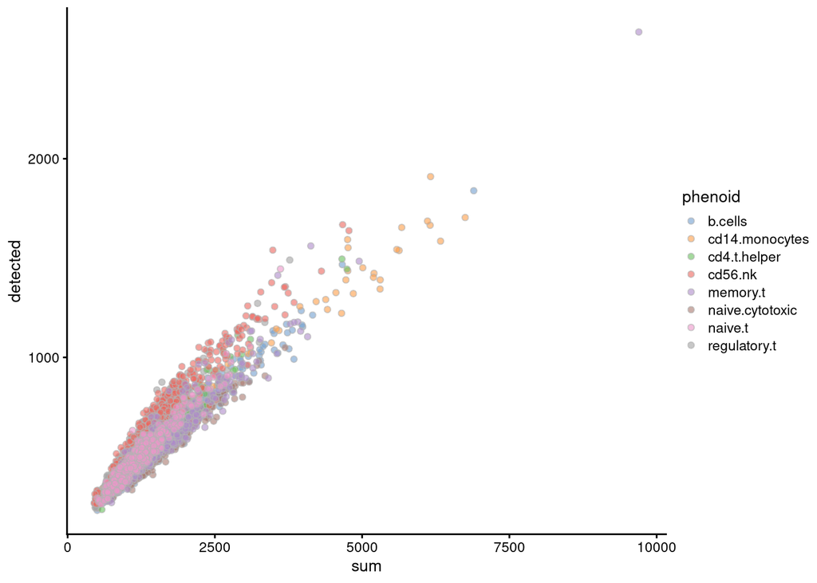

```r
plotColData(sce, x = "sum", y="detected", colour_by="phenoid")
```

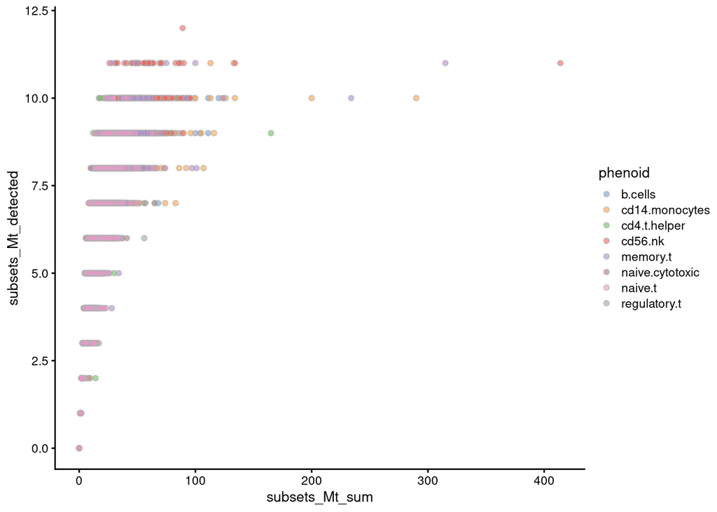

```r
plotColData(sce, x = "subsets_Mt_sum", y="subsets_Mt_detected", colour_by="phenoid")
```

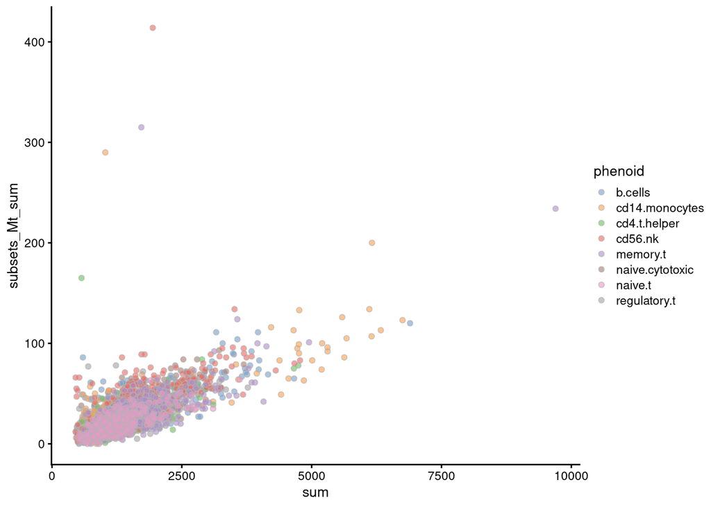

```r
plotColData(sce, x = "sum", y="subsets_Mt_sum", colour_by="phenoid")
```

```r
keep.total <- isOutlier(sce$sum, type="lower", log=TRUE)
filtering <- sce[, keep.total]
dim(filtering)
```

```
## [1] 15716     1
```

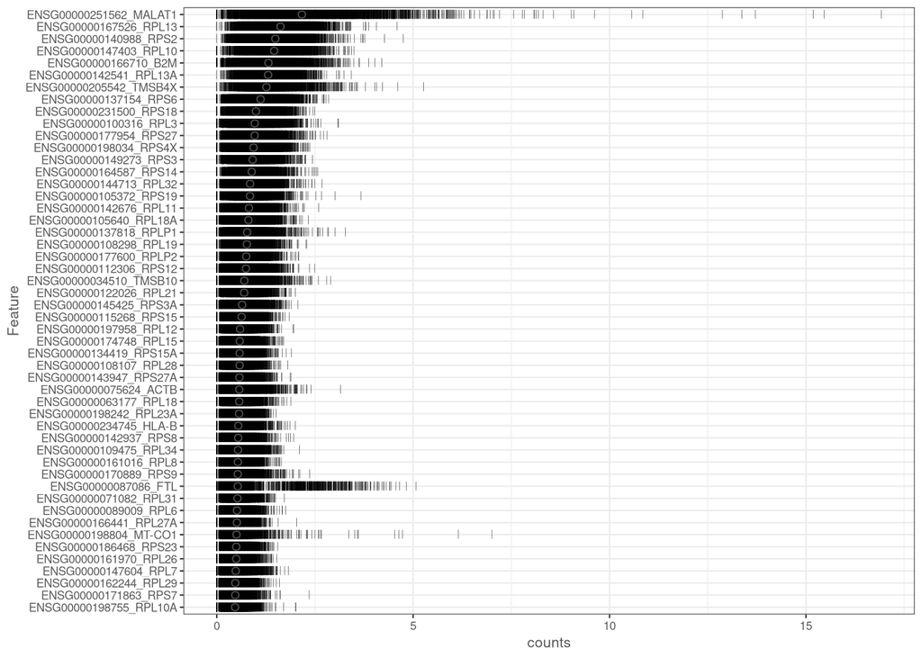

```r
plotHighestExprs(sce, exprs_values = "counts")
```

## Question 2

Identify “features of interest”, which usually means highly variable genes. There are various ways to do this (e.g., Seurat’s FindVariableFeatures or scran’s modelGeneVar). Select features in at least two ways (say, 1000-2000 genes) and make an upset plot to compare the lists:

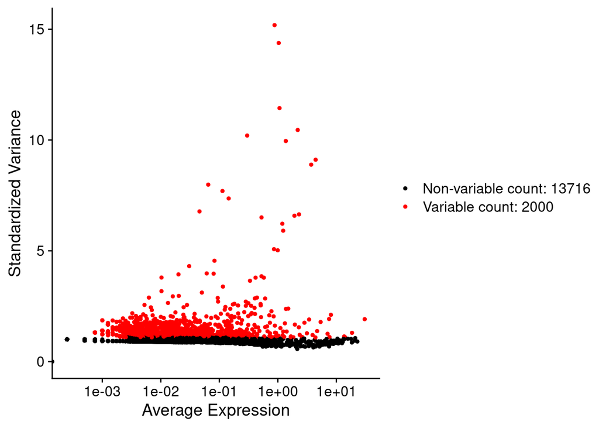

```r
library(dplyr)
library(Seurat)
library(scran)
library(UpSetR)

seurat_object <- as.Seurat(sce)
seurat_object <- NormalizeData(seurat_object)
variable_features_1 <- FindVariableFeatures(seurat_object, selection.method = "vst", nfeatures = 2000)
VariableFeaturePlot(variable_features_1)
```

```r
top_2000_1 <- head(VariableFeatures(variable_features_1), 2000)

scran_object <- modelGeneVar(sce, subset.fit=1:1000)
top_2000_2 <- getTopHVGs(scran_object, n=2000)
```

## Question 3

Re-calculate the low dimensional projection using your preferred set of selected features and produce some visualizations. For example, after re-running PCA, use the scater package to run the UMAP algorithm. Make multiple plots of the UMAP coordinates according to cell type (this is known in advance for this dataset), depth of sequencing and anything else you might find appropriate:

```r
pca <- runPCA(sce, name="PCA", subset_row= rownames(top_2000_1))
str(reducedDim(pca, "PCA"))
```

```
##  num [1:3994, 1:50] 0.103 0.513 1.026 -2.312 1.495 ...
##  - attr(*, "dimnames")=List of 2
##   ..$ : chr [1:3994] "b.cells1147" "b.cells6276" "b.cells6144" "b.cells6285" ...
##   ..$ : chr [1:50] "PC1" "PC2" "PC3" "PC4" ...
##  - attr(*, "percentVar")= num [1:50] 12.09 6.64 3.67 2.24 1.3 ...
```

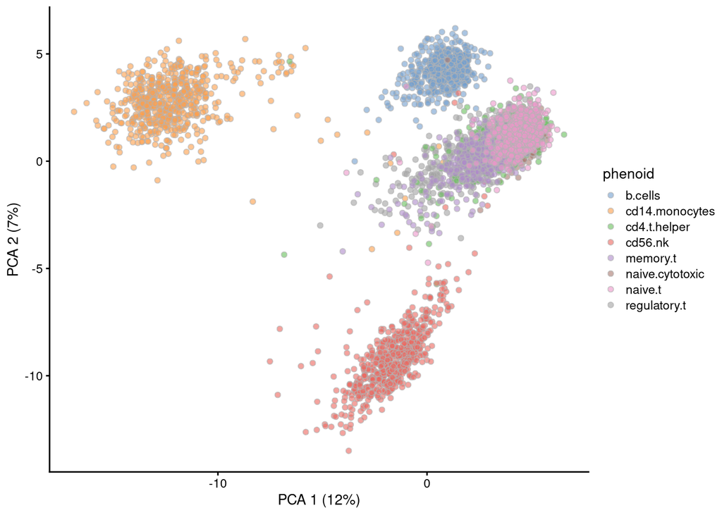

```r
plotPCA(pca, colour_by="phenoid")
```

```r
umap <- runUMAP(sce, subset_row = rownames(top_2000_1))
head(reducedDim(umap, "UMAP"))
```

```
##                 [,1]     [,2]
## b.cells1147 4.969315 8.028654
## b.cells6276 5.269636 8.122092
## b.cells6144 4.882649 7.617981
## b.cells6285 5.258042 7.484568
## b.cells8679 5.361955 7.757088
## b.cells6455 4.927895 7.739275
```

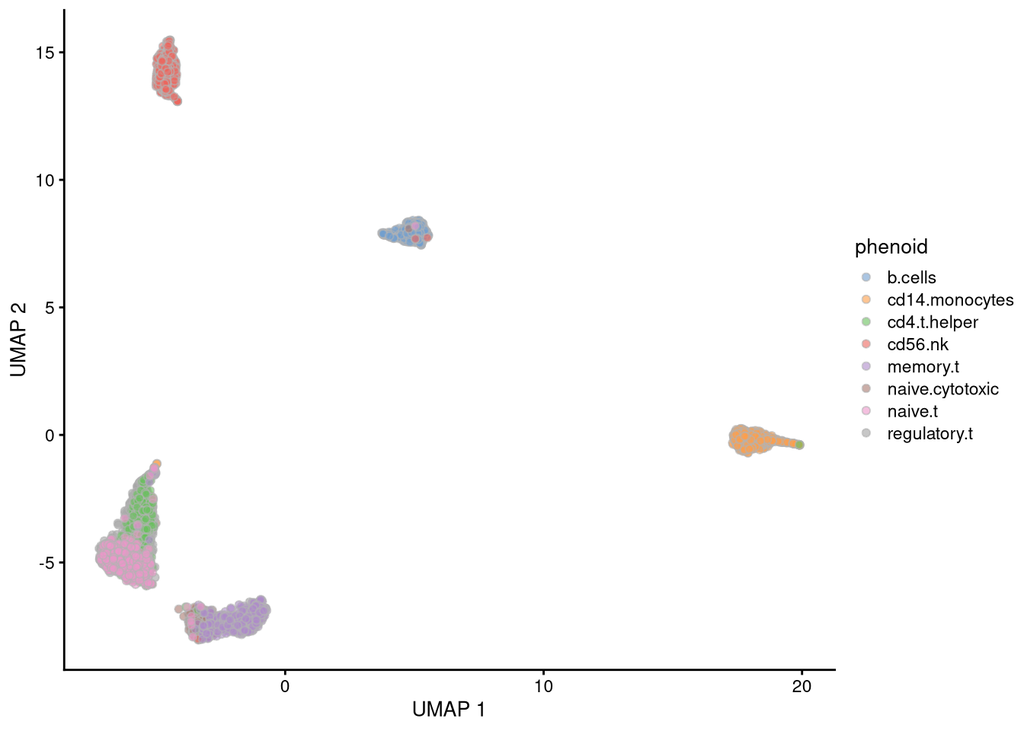

```r
plotReducedDim(umap, dimred = "UMAP", colour_by = "phenoid")
```

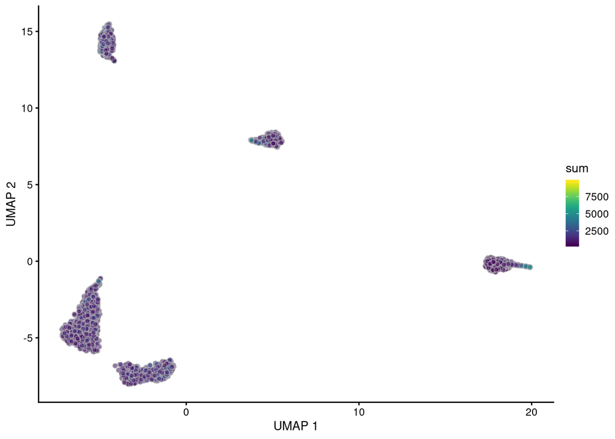

```r
plotReducedDim(umap, dimred = "UMAP", colour_by = "sum")
```

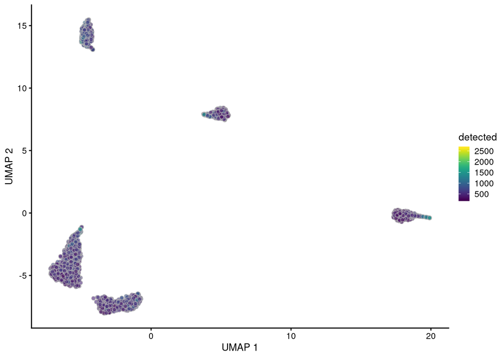

```r
plotReducedDim(umap, dimred = "UMAP", colour_by = "detected")
```

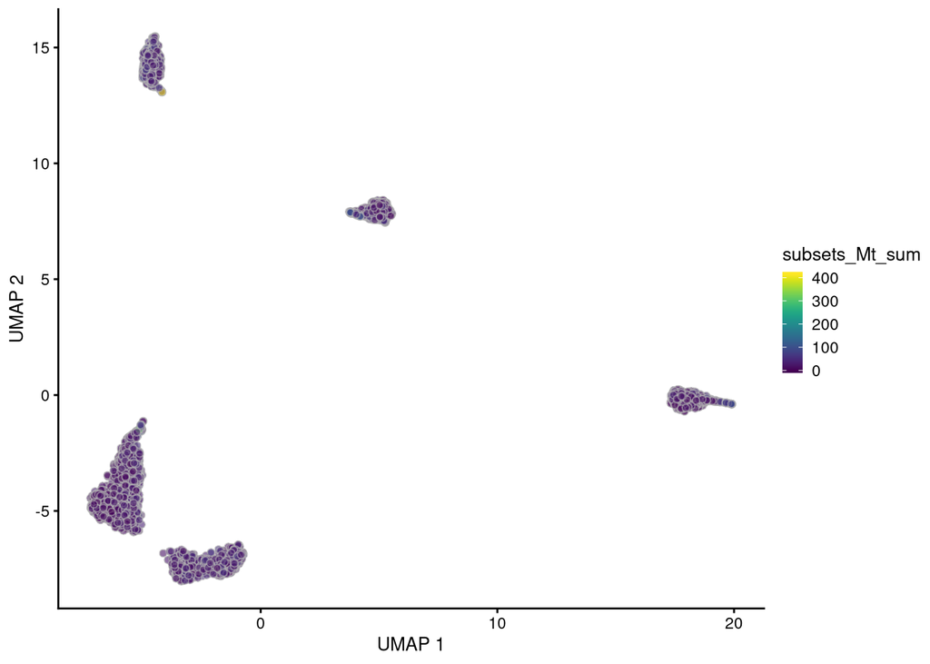

```r
plotReducedDim(umap, dimred = "UMAP", colour_by = "subsets_Mt_sum")
```

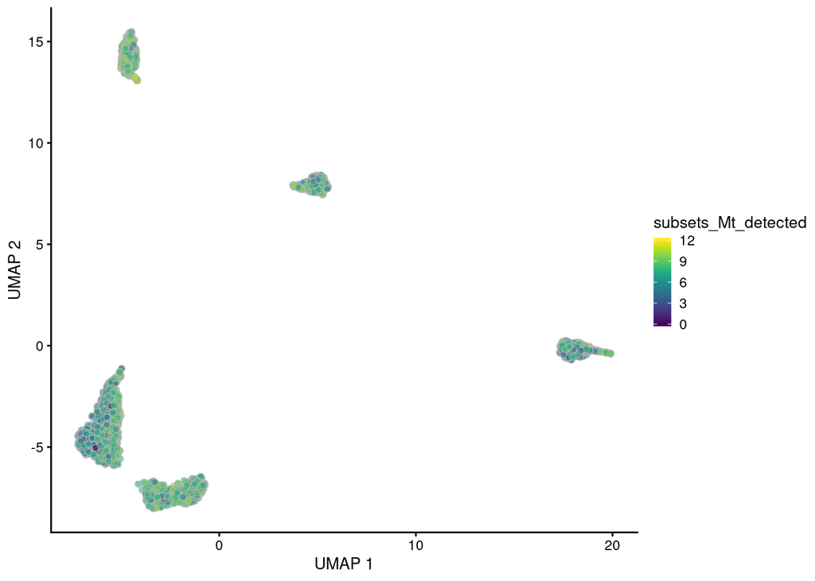

```r
plotReducedDim(umap, dimred = "UMAP", colour_by = "subsets_Mt_detected")
```

## Question 4

Run at least 2 algorithms to cluster the data and make some comparisons. One should be graph-based clustering as this seems to perform well, generally speaking. Calculate the F1 score for each cell type (solve_LSAP in the clue package may be useful for matching of clsuters to true populations) and the adjusted rand index (adjustedRandIndex in the mclust package, for example) for an overall score. What cell types are more difficult to separate with clustering? Run one of the algorithms at different numbers of clusters and plot a curve of the performance (e.g., adjusted rand index) as a function of the number of clusters:

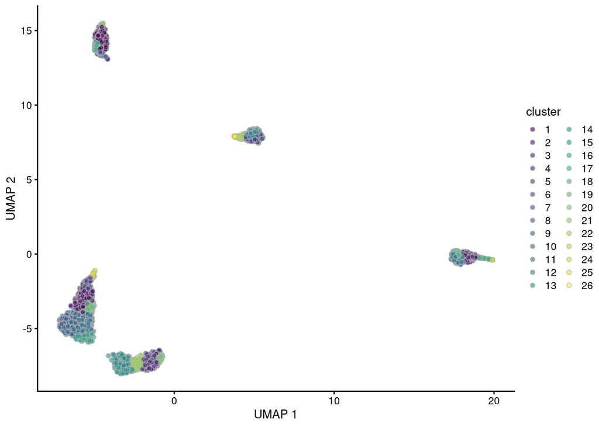

```r
library(pheatmap)

SNN_graph <- buildSNNGraph(umap, use.dimred="UMAP")
walktrap <- igraph::cluster_walktrap(SNN_graph)
cluster <- walktrap$membership
umap$cluster <- factor(cluster)
plotUMAP(umap, colour_by = "cluster")
```

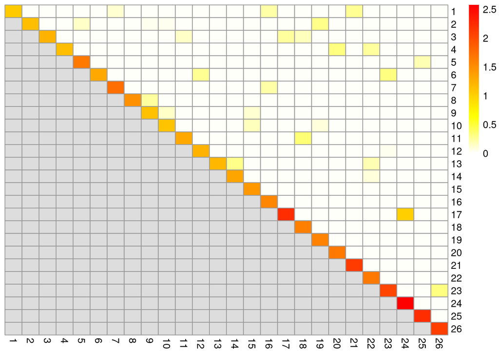

```r
cluster_modularity_ratio <- clusterModularity(SNN_graph, cluster, as.ratio=TRUE)
pheatmap(log10(cluster_modularity_ratio+1), cluster_cols=FALSE, cluster_rows=FALSE, col=rev(heat.colors(100)))
```

[figure not shown]

```r
hclust <- as.hclust(walktrap)
plot(as.dendrogram(hclust))
```

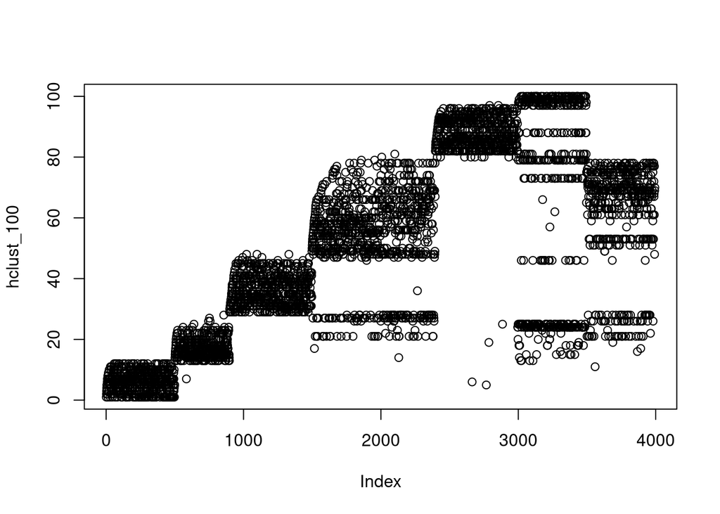

```r
hclust_100 <- cutree(hclust, k= 100)
plot(hclust_100)
```

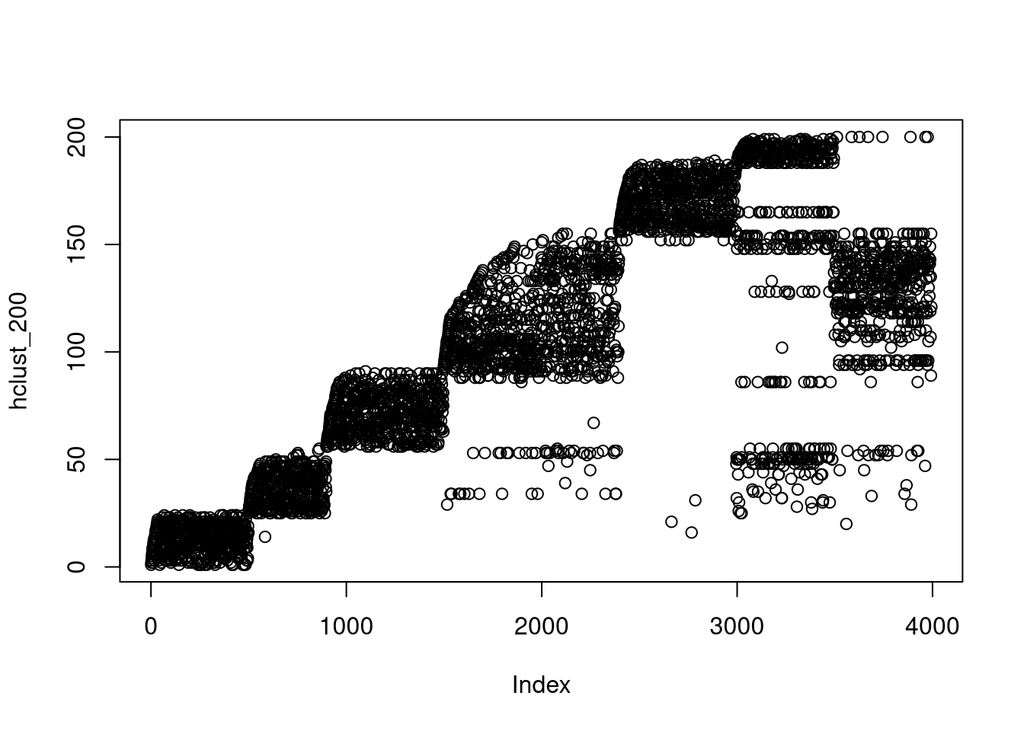

```r
hclust_200 <- cutree(hclust, k= 200)
plot(hclust_200)
```